# PROJEKTE

Modeli Holt–Winters me sezonalitet MULTIPLIKATIV

```r
# Modeli Holt–Winters me sezonalitet MULTIPLIKATIV
fit_hw_mul <- hw(myts_train, h = h_test, seasonal = "multiplicative")
```

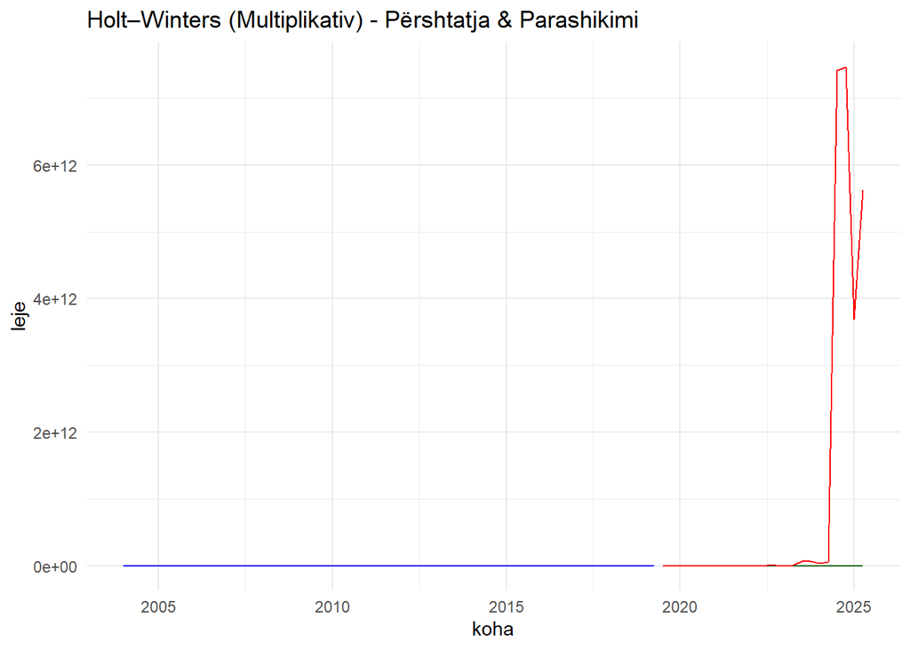

```r
# Grafik: train (real), fitted, test (real), forecast
autoplot(myts_train, series = "Train", color = "black") +
  autolayer(fitted(fit_hw_mul), series = "Përshtatja (Fitted)", color = "blue") +
  autolayer(myts_test, series = "Reale (Test)", color = "darkgreen") +
  autolayer(fit_hw_mul$mean, series = "Parashikimi (HW Multiplikativ)", color = "red") +
  labs(title = "Holt–Winters (Multiplikativ) - Përshtatja & Parashikimi",
       x = "koha", y = "leje") +
  guides(colour = guide_legend(title = "Serie")) +
  theme_minimal()
```

```r
# Saktësia dhe diagnostika (Multiplikativ)
acc_hw_mul <- accuracy(fit_hw_mul, myts_test)
acc_hw_mul
```

```
##                         ME         RMSE          MAE           MPE         MAPE
## Training set -6.170932e+00 1.635273e+02 1.129184e+02 -6.965725e+01 1.119545e+02
## Test set     -1.018191e+12 2.550953e+12 1.018191e+12 -3.146224e+11 3.146224e+11
##                      MASE      ACF1   Theil's U
## Training set 6.177386e-01 0.2116457          NA
## Test set     5.570185e+09 0.6399898 34663359365
```

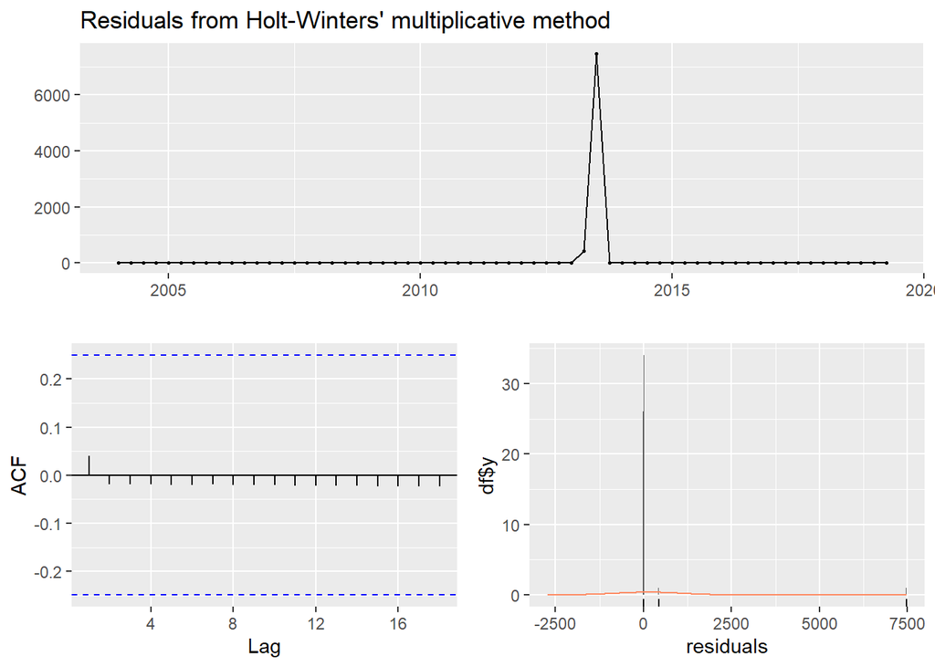

```
##
##  Ljung-Box test
##
## data:  Residuals from Holt-Winters' multiplicative method
## Q* = 0.29297, df = 8, p-value = 1
##
## Model df: 0.   Total lags used: 8
```

```r
checkresiduals(fit_hw_mul)
```

Edhe pse seria kohore përmban vetëm vlera pozitive (minimumi 12), modeli Holt–Winters multiplicative rezulton i papërshtatshëm. Analiza grafike tregon se sezonaliteti ka amplitudë pothuajse konstante dhe nuk rritet proporcionalisht me nivelin e serisë, duke shkelur supozimin bazë të modelit multiplicative. Si pasojë, modeli prodhon parashikime numerikisht të paqëndrueshme, me shpërthime artificiale të vlerave, çka justifikon përdorimin e variantit additive. Analiza diagnostike e moelit Holt-Winters multuplicative tregon se residualet shfaqin shperndarje shum asimetrike, variance jokonstante dhe outliers ekstreme, duke shkelur supozimet baze te modelit. Holt-Winters multiplicativ nuk deshtoi per shkak te zeros, por sepse sezonaliteti nuk shkallezohet propocionalisht me nivelin e serise.

Krahasimi i saktësisë së modeleve

```r
library(tibble)
acc_table <- bind_rows(
  data.frame(Model = "SES",            accuracy(fit_ses, myts_test)),
  data.frame(Model = "Holt",           accuracy(fit_holt, myts_test)),
  data.frame(Model = "HW Additive",    accuracy(fit_hw_add, myts_test)),
  data.frame(Model = "HW Multiplicative", accuracy(fit_hw_mul, myts_test)),

)

# Zgjedhim kolonat më përfaqësuese dhe renditim sipas RMSE
acc_table <- acc_table %>%
  select(Model, RMSE, MAE, MAPE, MASE) %>%
  arrange(RMSE)

knitr::kable(acc_table, caption = "Krahasimi i performancës së modeleve ")
```

Krahasimi i performancës së modeleve

|  | Model | RMSE | MAE | MAPE | MASE |
| --- | --- | --- | --- | --- | --- |
| Test set…1 | HW Additive | 8.238663e+01 | 6.527601e+01 | 2.119286e+01 | 3.571032e-01 |
| Test set…2 | Holt | 8.832775e+01 | 7.200401e+01 | 2.172554e+01 | 3.939099e-01 |
| Test set…3 | SES | 8.930234e+01 | 7.272566e+01 | 2.168427e+01 | 3.978578e-01 |
| Training set…4 | HW Multiplicative | 1.635273e+02 | 1.129184e+02 | 1.119545e+02 | 6.177386e-01 |
| Training set…5 | HW Additive | 1.965849e+02 | 1.535313e+02 | 1.621950e+02 | 8.399185e-01 |
| Training set…6 | SES | 2.348331e+02 | 1.707298e+02 | 1.963030e+02 | 9.340055e-01 |
| Training set…7 | Holt | 2.357764e+02 | 1.705482e+02 | 1.869830e+02 | 9.330123e-01 |
| Test set…8 | HW Multiplicative | 2.550953e+12 | 1.018191e+12 | 3.146224e+11 | 5.570185e+09 |

Krahasimi i performancës së modeleve tregon se Holt–Winters additive ka gabimet më të ulëta në test set (RMSE ≈ 82.39, MAPE ≈ 21.19%, MASE ≈ 0.36), duke rezultuar modeli më i përshtatshëm për parashikim. Modelet SES dhe Holt paraqesin performancë më të dobët për shkak të mungesës së komponentës sezonale. Ndërkohë, Holt–Winters multiplicative prodhon gabime ekstremisht të larta, duke treguar paqëndrueshmëri numerike dhe keq-specifikim të modelit. Kjo konfirmon se për këtë seri kohore varianti additive është zgjedhja e duhur.

## Modeli më i mirë dhe parashikimi 12-tremujor

```r
best_model <- acc_table$Model[1]
best_model
```

```
## [1] "HW Additive"
```

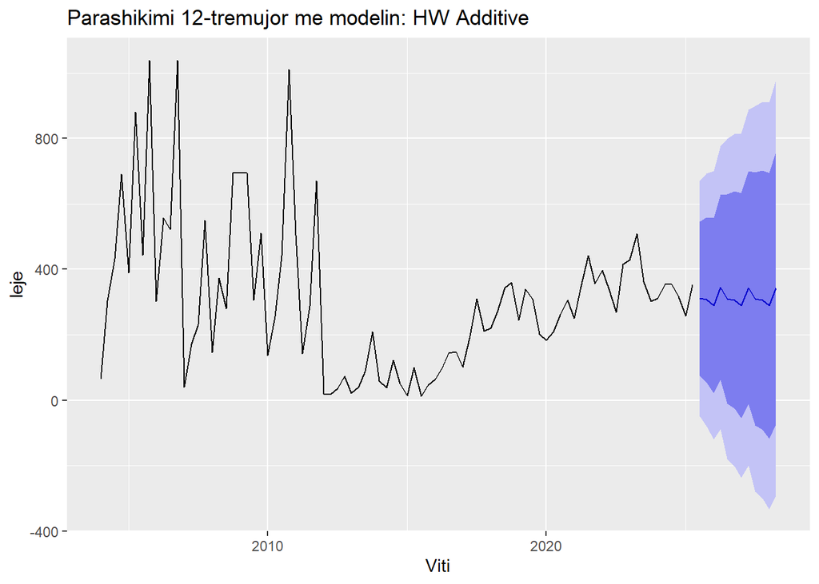

```r
final_fit <- switch(best_model,
                    "SES" = ses(myts, h = 12),
                    "Holt" = holt(myts, h =12, damped = FALSE),
                    "HW Additive" = hw(myts, h = 12, seasonal = "additive"),
                    "HW Multiplicative" = hw(myts, h = 12, seasonal = "multiplicative"))


autoplot(final_fit) +
  ggtitle(paste0("Parashikimi 12-tremujor me modelin: ", best_model)) +
  xlab("Viti") + ylab("leje")
```

Bazuar në krahasimin e performancës, modeli Holt–Winters additive u zgjodh si modeli më i mirë dhe u aplikua mbi serinë e plotë për të gjeneruar parashikimin 12-tremujor. Rezultatet tregojnë një trend të qëndrueshëm me luhatje sezonale të ngjashme me periudhën historike, ndërsa intervalet e besimit reflektojnë pasigurinë në rritje të parashikimit afatmesëm. Holt–Winters additive ofron parashikim realist dhe stabil, në përputhje me strukturën sezonale të të dhënave, ndryshe nga varianti multiplicative që rezultoi i paqëndrueshëm.

## Rezultatet e parashikimit

```r
library(lubridate)

# Nxjerrim vektorin e kohëve nga parashikimi
t <- time(final_fit$mean)

# Kthejmë në data mujore (dita e parë e muajit)
Muaji <- as.Date(paste(floor(t), round(12 * (t - floor(t)) + 1), "01", sep = "-"))

# Ndërtojmë tabelën
final_fc_tbl <- tibble(
  Muaji = Muaji,
  Parashikim = as.numeric(final_fit$mean),
  Lwr95 = as.numeric(final_fit$lower[, "95%"]),
  Upr95 = as.numeric(final_fit$upper[, "95%"])
)

knitr::kable(final_fc_tbl, caption = "Parashikimi 12-tremujor me intervale besimi 95%")
```

Parashikimi 12-tremujor me intervale besimi 95%

| Muaji | Parashikim | Lwr95 | Upr95 |
| --- | --- | --- | --- |
| 2025-07-01 | 310.8339 | -49.27137 | 670.9393 |
| 2025-10-01 | 307.1735 | -78.28412 | 692.6311 |
| 2026-01-01 | 289.9906 | -119.26382 | 699.2451 |
| 2026-04-01 | 344.3713 | -87.38181 | 776.1244 |
| 2026-07-01 | 310.1997 | -178.48254 | 798.8820 |
| 2026-10-01 | 306.5393 | -201.15327 | 814.2318 |
| 2027-01-01 | 289.3564 | -236.66925 | 815.3820 |
| 2027-04-01 | 343.7371 | -200.01304 | 887.4872 |
| 2027-07-01 | 309.5655 | -280.45972 | 899.5907 |
| 2027-10-01 | 305.9050 | -299.99164 | 911.8017 |
| 2028-01-01 | 288.7222 | -332.64868 | 910.0930 |
| 2028-04-01 | 343.1028 | -293.37388 | 979.5795 |

Parashikimi 12-tremujor me modelin Holt–Winters additive tregon stabilitet të numrit të lejeve me luhatje sezonale të moderuara. Intervalet e besimit 95% zgjerohen gradualisht në kohë, duke reflektuar rritjen e pasigurisë së parashikimit afatmesëm. Intervalet e besimit tregojnë se parashikimi është i qëndrueshëm, ndërsa pasiguria rritet gradualisht pa sinjale për ndryshime strukturore.

Proceset MA dhe AR

```r
# Ngarkojme librarine qe do na duhet
library(ggplot2)
library(forecast)
set.seed(42)

n <- 50 # Numri i pikave kohore
```

# MA

## MA(1)

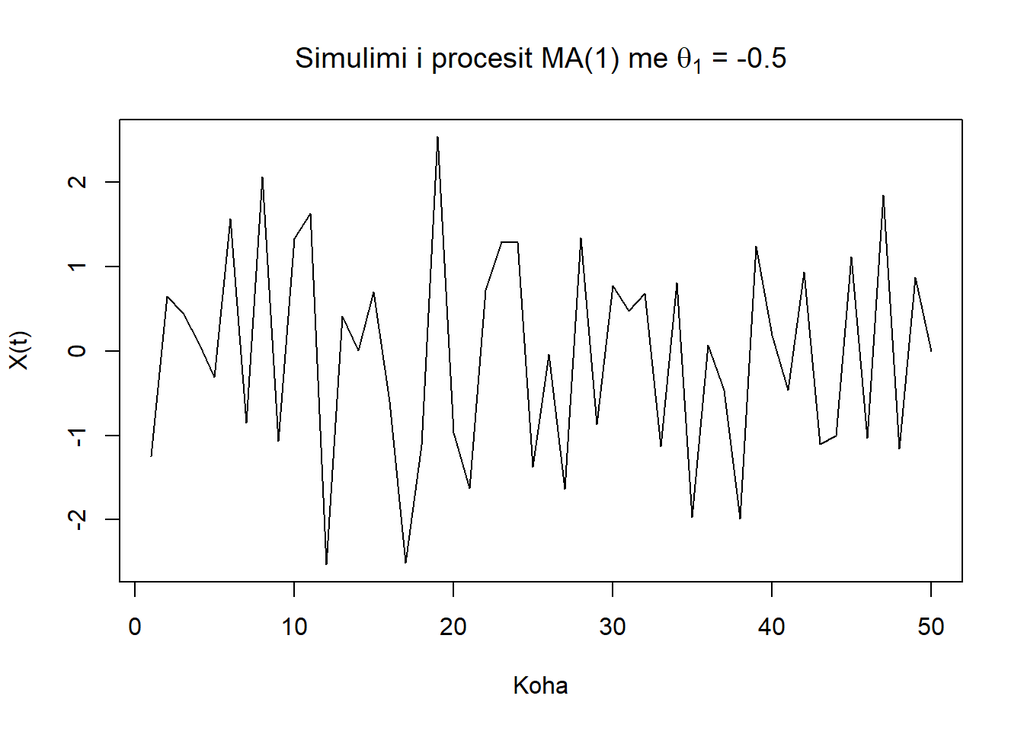

```r
myts_ma1_neg05 <- arima.sim(model = list(ma = c(-0.5)), n = n)

# Grafiku i serise kohore
plot(myts_ma1_neg05, main = expression(paste("Simulimi i procesit MA(1) me ", theta[1], " = -0.5")),
     ylab = "X(t)", xlab = "Koha")
```

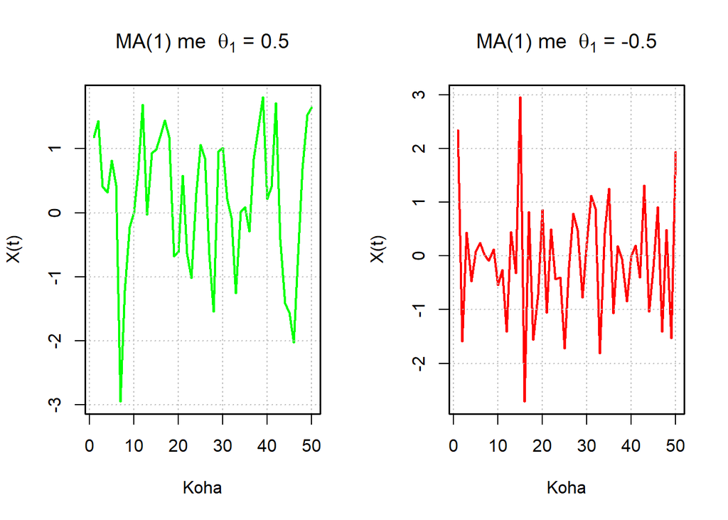

```r
# Simulimet

myts_ma_pos <- arima.sim(model = list(ma = 0.5), n = n)
myts_ma_neg <- arima.sim(model = list(ma = -0.5), n = n)

# Vendos 2 grafikë horizontalisht
par(mfrow = c(1, 2))

# Grafik 1: theta = 0.5
plot(myts_ma_pos,
     type = "l",
     col = "green",
     lwd = 2,
     main = expression(paste("MA(1) me  ", theta[1], " = 0.5")),
     xlab = "Koha",
     ylab = "X(t)")
grid(col = "gray")
box(lwd = 1.5)

# Grafik 2: theta = -0.5
plot(myts_ma_neg,
     type = "l",
     col = "red",
     lwd = 2,
     main = expression(paste("MA(1) me  ", theta[1], " = -0.5")),
     xlab = "Koha",
     ylab = "X(t)")
grid(col = "gray")
box(lwd = 1.5)
```

```r
par(mfrow = c(1,1))
```

Grafiku i MA(1) tregon se për theta1=0.5 seria shfaq persistencë dhe luhatje më të buta, ndërsa për theta2=-0.5 shfaqet sjellje zig-zag për shkak të autocorrelation-it negativ në lag 1. Në të dy rastet, varësia kohore zhduket pas lag 1, në përputhje me vetitë teorike të modeleve MA(1).

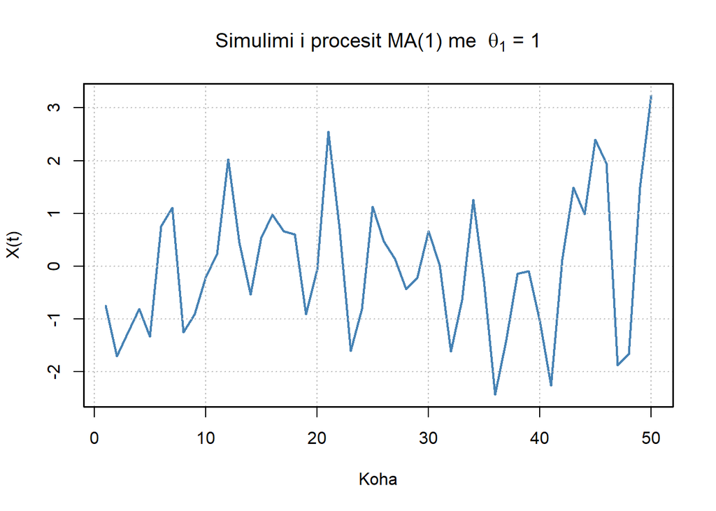

```r
myts_ma1_neg05 <- arima.sim(model = list(ma = 1), n = n)

# Grafik i përmirësuar
plot(myts_ma1_neg05,
     type = "l",
     col = "steelblue",
     lwd = 2,
     main = expression(paste("Simulimi i procesit MA(1) me  ", theta[1], " = 1")),
     xlab = "Koha",
     ylab = "X(t)")

grid(col = "gray")
box(lwd = 1.5)
```

## ACF, ACVF, dhe PACF për Proceset MA(1)

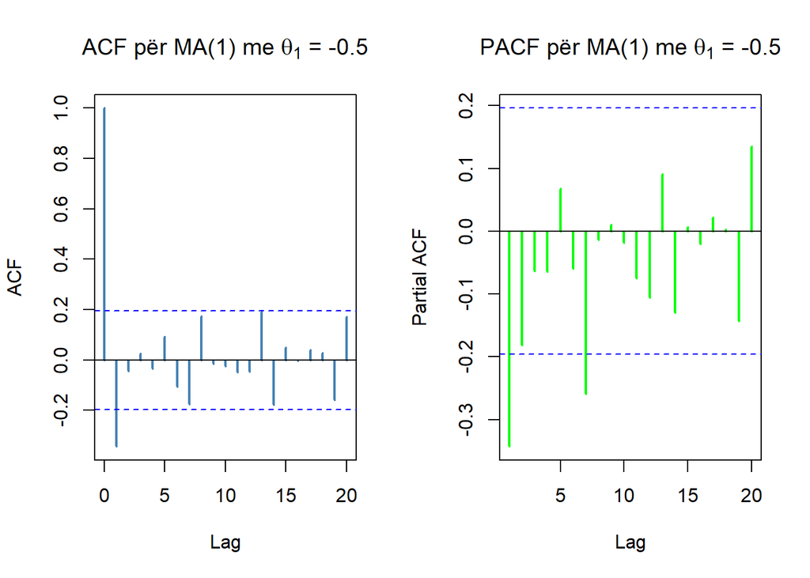

```r
# Simulimi i procesit MA(1) me theta = -0.5
set.seed(42)
myts_ma1_neg05 <- arima.sim(model = list(ma = -0.5), n = 100)

# ACF dhe PACF për procesin MA(1)
par(mfrow = c(1, 2))

acf(myts_ma1_neg05,
    main = expression(paste("ACF për MA(1) me ", theta[1], " = -0.5")),
    col = "steelblue",
    lwd = 2)

pacf(myts_ma1_neg05,
     main = expression(paste("PACF për MA(1) me ", theta[1], " = -0.5")),
     col = "green",
     lwd = 2)
```

Për procesin MA(1) me θ₁ = −0.5, funksioni i autokorrelacionit (ACF) paraqet një korrelacion domethënës vetëm në lagun e parë dhe bie në zero për lagët pasues, ndërsa PACF shfaq një zbehje graduale. Kjo sjellje konfirmon strukturën tipike të një procesi Moving Average të rendit të parë. Në një proces MA(1), ACF pritet pas lagut të parë, ndërsa PACF zbehet gradualisht.

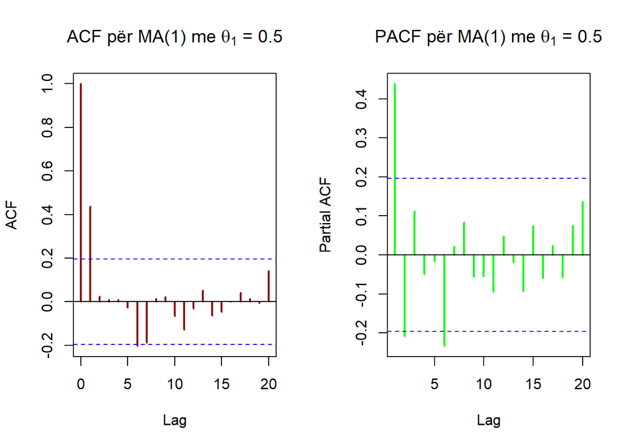

```r
# Simulimi i procesit MA(1) me theta = 0.5
set.seed(42)
myts_ma1_neg05 <- arima.sim(model = list(ma = 0.5), n = 100)

# ACF dhe PACF për procesin MA(1)
par(mfrow = c(1, 2))

acf(myts_ma1_neg05,
    main = expression(paste("ACF për MA(1) me ", theta[1], " = 0.5")),
    col = "darkred",
    lwd = 2)

pacf(myts_ma1_neg05,
     main = expression(paste("PACF për MA(1) me ", theta[1], " = 0.5")),
     col = "green",
     lwd = 2)
```

Ndryshimi midis θ₁ pozitiv dhe negativ qëndron në drejtimin e reagimit ndaj shokëve, ndërsa struktura MA(1) mbetet e pandryshuar. Me “shokë” nënkuptohen devijime të paparashikuara nga trendi dhe sezonaliteti, si ndryshime politike, ekonomike apo administrative, të cilat ndikojnë përkohësisht në seri.

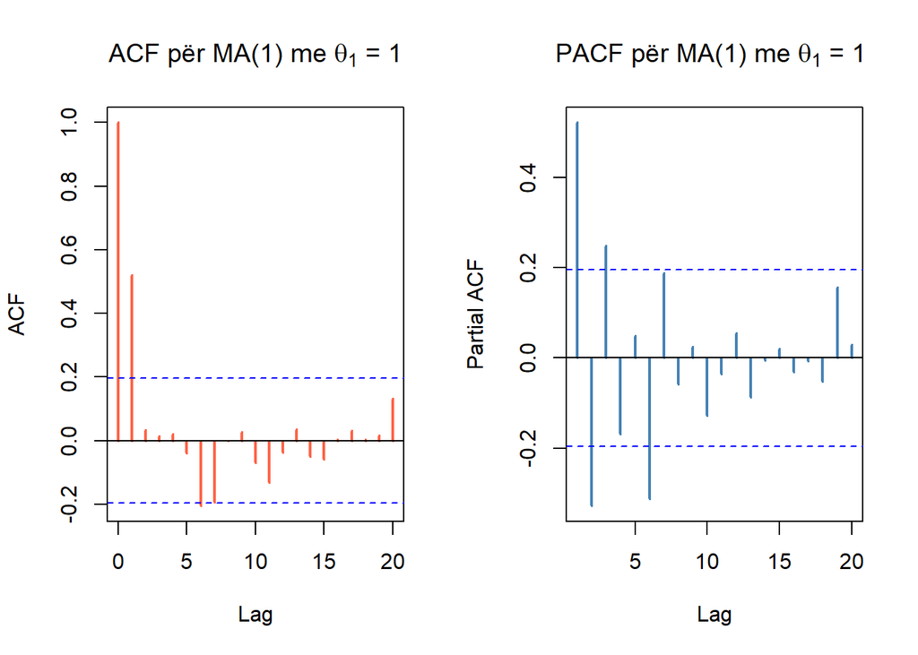

```r
# Simulimi i procesit MA(1) me theta = -1
set.seed(42)
ts_ma1_neg05 <- arima.sim(model = list(ma = 1), n = 100)

# ACF dhe PACF për procesin MA(1)
par(mfrow = c(1, 2))

acf(ts_ma1_neg05,
    main = expression(paste("ACF për MA(1) me ", theta[1], " = 1")),
    col = "tomato",
    lwd = 2)

pacf(ts_ma1_neg05,
     main = expression(paste("PACF për MA(1) me ", theta[1], " = 1 ")),
     col = "steelblue",
     lwd = 2)
```